# Inference from linear models

8 April 2026

## Goals for today

- Understand the concept and practice of partitioning sums-of-squares
- Understand the uses of R<sup>2</sup> and adjusted-R<sup>2</sup> for linear models

## General approach

### Question \(\rightarrow\) Data \(\rightarrow\) Model \(\rightarrow\) Inference \(\rightarrow\) Prediction

## Inference

### Relationship(s) between predictor(s) and response

- How big is an effect? Is an effect “important”?
- How certain are we about the sign and size of the effect?

## General approach

### Question \(\rightarrow\) Data \(\rightarrow\) Model \(\rightarrow\) Inference \(\rightarrow\) Prediction

## Prediction

- What do we predict for a novel case?
- How good will our predictions be?

## Partitioning variance

In general, we have something like

\[ DATA = MODEL + ERRORS \]

and hence

\[ \text{Var}(DATA) = \text{Var}(MODEL) + \text{Var}(ERRORS) \]

## Partitioning total deviations

The total deviations in the data equal the sum of those for the model and errors

\[ \underbrace{y_i - \bar{y}}_{\text{Total}} = \underbrace{\widehat{y}_i - \bar{y}}_{\text{Model}} + \underbrace{y_i - \widehat{y}_i}_{\text{Error}} \]

## Partitioning variance

### An example

Let’s consider a model for the relationship between

- soil surface temperature (C) measured across 15 small plots on a hill, and
- the aspect of each plot (direction in degrees; N to S)

## Partitioning variance

### An example

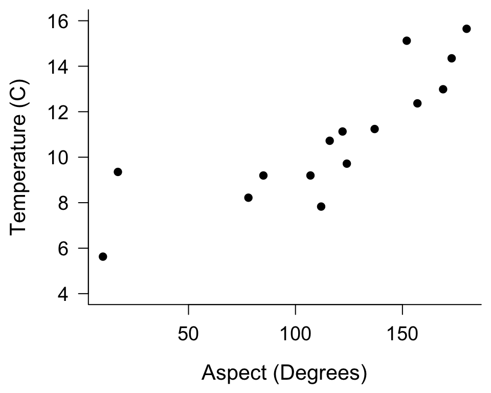

## Partitioning variance

### An example

Let’s fit this model:

\[temperature_i = \beta_0 + \beta_1 \times aspect_i + e_i\]

and estimate \(\hat{\boldsymbol{\beta}}\) and \(\hat{\boldsymbol{y}}\)

*Let’s use matrix algebra like we learned last time!*

## Partitioning variance

### An example

Create our design matrix \(\mathbf{X}\)

```r
## construct our "design matrix"
XX <- cbind(intercept = rep(1, nn), x = aspect)
head(XX)
```

```
##      intercept   x
## [1,]         1 180
## [2,]         1 122
## [3,]         1  10
## [4,]         1  17
## [5,]         1 157
## [6,]         1  85
```

## Partitioning variance

### An example

We can calculate our betas using

\(\hat{\boldsymbol{\beta}} = (\mathbf{X}^{\top} \mathbf{X})^{-1} \mathbf{X}^{\top} \mathbf{y}\)

```r
## calculate betas
beta_hat <- solve(t(XX) %*% XX) %*% t(XX) %*% temp
```

`t()` transforms (rotates) a matrix and `solve()` inverts it

`%*%` denotes matrix multiplication

## Partitioning variance

### An example

We can calculate our model estimates (\(\hat{\mathbf{y}}\)) using

\(\hat{\mathbf{y}} = \mathbf{X}\hat{\boldsymbol{\beta}}\)

```r
## calculate model estimates
temp_hat <- XX %*% beta_hat
```

## Partitioning variance

### An example

Let’s plot our model estimates (ie, the fitted regression line)

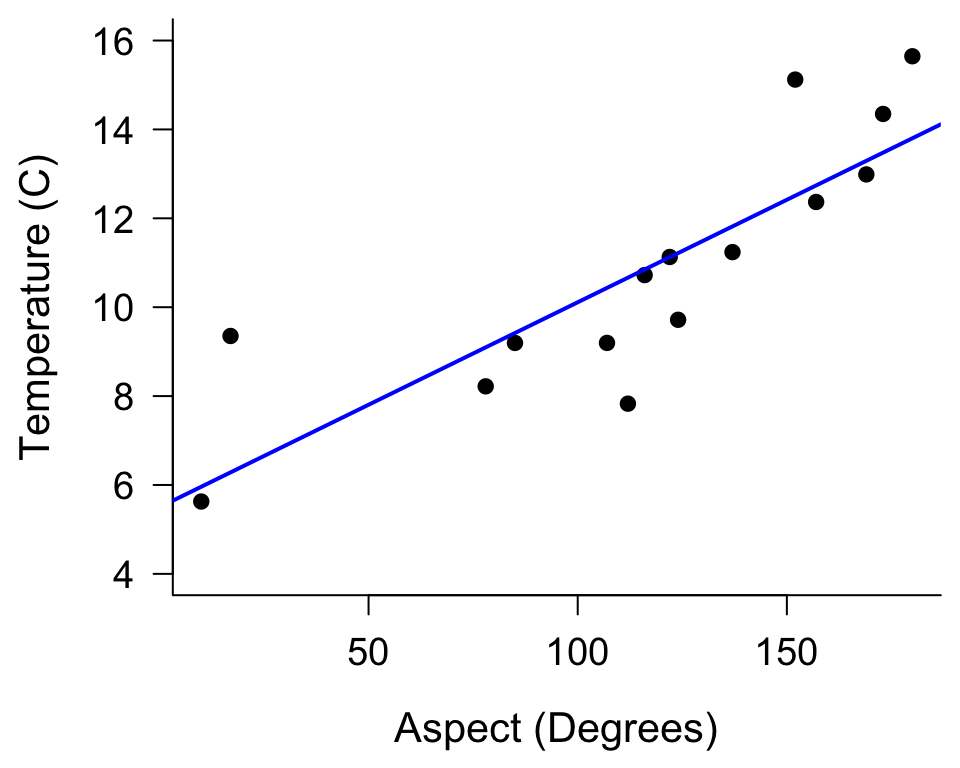

## Partitioning total deviations

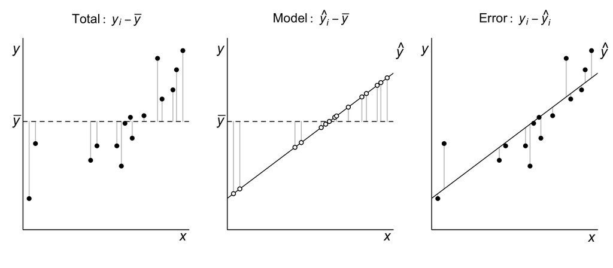

## Partitioning sums-of-squares

The sums-of-squares have the same additive property as the deviations

\[ \underbrace{\sum (y_i - \bar{y})^2}_{SSTO} = \underbrace{\sum (\widehat{y}_i - \bar{y})^2}_{SSR} + \underbrace{\sum (y_i - \widehat{y}_i)^2}_{SSE} \]

## Sum-of-squares: Total

The total sum-of-squares \((SSTO)\) measures the total variation in the data as the differences between the data and their mean

\[ SSTO = \sum \left( y_i - \bar{y} \right)^2 \]

## Sum-of-squares: Model

The model (regression) sum-of-squares \((SSR)\) measures the variation between the model fits and the mean of the data

\[ SSR = \sum \left( \widehat{y}_i - \bar{y} \right)^2 \]

## Sum-of-squares: Error

The error sum-of-squares \((SSE)\) measures the variation between the data and the model fits

\[ SSE = \sum \left( y_i - \widehat{y}_i \right)^2 \]

## Sum-of-squares

### An example

Let’s calculate the total sum-of-squares (SSTO) using

\(SSTO = \sum \left( y_i - \bar{y} \right)^2\)

```r
## mean of the response
temp_bar <- mean(temp)

## total sum-of-squares
SSTO <- t(temp - temp_bar) %*% (temp - temp_bar)
```

Recall that \(\mathbf{x}^{\top} \mathbf{x}\) will give the sum of the squared elements in \(\mathbf{x}\)

## Sum-of-squares

### An example

Let’s calculate the model sum-of-squares (SSR) using

\(SSR = \sum \left( \widehat{y}_i - \bar{y} \right)^2\)

```r
## model sum-of-squares
SSR <- t(temp_hat - temp_bar) %*% (temp_hat - temp_bar)
```

## Sum-of-squares

### An example

Let’s calculate the error sum-of-squares (SSE) using

\(SSE = \sum \left( y_i - \widehat{y}_i \right)^2\)

```r
## error sum-of-squares
SSE <- t(temp - temp_hat) %*% (temp - temp_hat)
```

## QUESTIONS?

## Goodness-of-fit

How about a measure of how well a model fits the data?

- \(SSTO\) measures the variation in \(y\) *without* considering \(X\)
- \(SSE\) measures the reduced variation in \(y\) *after* considering \(X\)
- Let’s consider this reduction in variance as a proportion of the total

## Goodness-of-fit

A common option is the *coefficient of determination* or \((R^2)\)

\[ R^2 = \frac{SSR}{SSTO} = 1 - \frac{SSE}{SSTO} \\ ~ \\ 0 < R^2 < 1 \]

## Goodness-of-fit

### An example

Let’s calculate the \((R^2)\) for our model

```r
## coefficient of determination
SSR / SSTO
```

```
##           [,1]
## [1,] 0.7011654
```

```r
## or via
1 - SSE / SSTO
```

```
##           [,1]
## [1,] 0.7011654
```

## Degrees of freedom

The number of *independent* elements that are free to vary when estimating quantities of interest

## Degrees of freedom

### An example

- Imagine you have 7 hats and you want to wear a different one on each day of the week
- On day 1 you can choose any of the 7, on day 2 any of the remaining 6, and so forth
- When day 7 rolls around, however, you are out of choices: there is only one unworn hat
- Thus, you had 7 - 1 = 6 days of freedom to choose your hat

## Model in geometric space

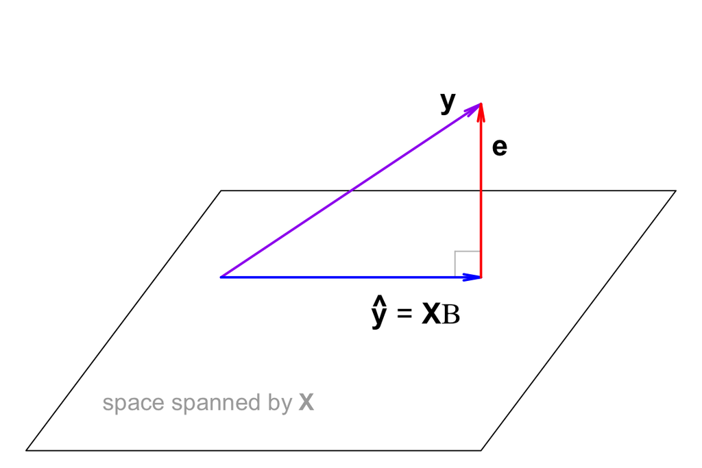

\(\mathbf{y}\) is \(n\)-dim; \(\widehat{\mathbf{y}}\) is \(k\)-dim; \(\mathbf{e}\) is \((n-k)\)-dim

## Degrees of freedom

### Linear models

Beginning with \(SSTO\), we have

\[ SSTO = \sum \left( y_i - \bar{y} \right)^2 \]

The data are unconstrained and lie in an \(n\)-dimensional space, but estimating the mean \((\bar{y})\) from the data costs 1 degree of freedom \((df)\), so

\[ df_{SSTO} = n - 1 \]

## Degrees of freedom

### Linear models

For the \(SSR\) we have

\[ SSR = \sum \left( \widehat{y}_i - \bar{y} \right)^2 \]

We estimate the data \((\widehat{y})\) with a \(k\)-dimensional model, but we lose 1 \(df\) when estimating the mean, so

\[ df_{SSR} = k - 1 \]

## Degrees of freedom

### Linear models

The \(SSE\) is analogous

\[ SSE = \sum \left( y_i - \widehat{y}_i \right)^2 \]

The data lie in an \(n\)-dimensional space and we represent them in a \(k\)-dimensional subspace, so

\[ df_{SSE} = n - k \]

## Mean squares

The expectation of the sum-of-squares or “mean square” gives an indication of the variance for the model and errors

## Mean squares

The expectation of the sum-of-squares or “mean square” gives an indication of the variance for the model and errors

A mean square is a sum-of-squares divided by its degrees of freedom

\[ MS = \frac{SS}{df} \\ \]

## Mean squares

Mean square model

\(MSR = \frac{SSR}{k - 1}\)

Mean square error

\(MSE = \frac{SSE}{n - k}\)

## Variance estimates

We are typically interested in two variance estimates:

1. The variance of the residuals \(\mathbf{e}\)
2. The variance of the model parameters \(\mathbf{B}\)

## Variance estimates

### Residuals

In a least squares context, we assume that the model errors (residuals) are independent and identically distributed with mean 0 and variance \(\sigma^2\)

The problem is that we don’t know \(\sigma^2\) and therefore we must estimate it

## Variance estimates

### Residuals

If \(z_i \sim \text{N}(0, 1)\) then

\[ \sum_{i = 1}^{n} z_i^2 = \mathbf{z}^{\top}\mathbf{z} \\ \Downarrow \\ \mathbf{z}^{\top}\mathbf{z} \sim \chi^2_{n} \]

## Variance estimates

### Residuals

In our linear model, \(e_i \sim \text{N}(0, \sigma^2)\) so

\[ \sum_{i = 1}^{n} e_i^2 = \mathbf{e}^{\top}\mathbf{e} \\ \Downarrow \\ \mathbf{e}^{\top}\mathbf{e} \sim \sigma^2 \cdot \chi^2_{n - k} \]

## Variance estimates

### Residuals

So, if

\[ \mathbf{e}^{\top}\mathbf{e} \sim \sigma^2 \cdot \chi^2_{n - k} \]

then the *expectation* (mean) is

\[ \text{E}(\mathbf{e}^{\top}\mathbf{e}) = \sigma^2 ~ \text{E}(\chi^2_{n - k}) \]

## Variance estimates

### Residuals

Thus, given

\[ \text{E}(\mathbf{e}^{\top}\mathbf{e}) = \sigma^2 ~ \text{E}(\chi^2_{n - k}) \\ \Downarrow \\ SSE = \sigma^2 (n - k) \\ \Downarrow \\ \sigma^2 = \frac{SSE}{n - k} = MSE \]

## Variance estimates

### Parameters

Recall that our estimate of the model parameters is

\[ \widehat{\boldsymbol{\beta}} = (\mathbf{X}^{\top} \mathbf{X})^{-1} \mathbf{X}^{\top} \mathbf{y} \]

## Variance estimates

### Parameters

Estimating the variance of the model parameters \(\boldsymbol{\beta}\) requires some linear algebra

- for a scalar \(z\), if \(\text{Var}(z) = \sigma^2\) then \(\text{Var}(az) = a^2 \sigma^2\)
- for a vector \(\mathbf{z}\), if \(\text{Var}(\mathbf{z}) = \mathbf{\Sigma}\) then \(\text{Var}(\mathbf{A z}) = \mathbf{A} \mathbf{\Sigma} \mathbf{A}^{\top}\)

## Variance estimates

### Parameters

The variance of the parameters is therefore

\[ \begin{aligned} \widehat{\boldsymbol{\beta}} &= (\mathbf{X}^{\top} \mathbf{X})^{-1} \mathbf{X}^{\top} \mathbf{y} \\ &= \left[ (\mathbf{X}^{\top} \mathbf{X})^{-1} \mathbf{X}^{\top} \right] \mathbf{y} \\ \end{aligned} \\ \Downarrow \\ \text{Var}(\widehat{\boldsymbol{\beta}}) = \left[ (\mathbf{X}^{\top} \mathbf{X})^{-1} \mathbf{X}^{\top} \right] \text{Var}(\mathbf{y}) \left[ (\mathbf{X}^{\top} \mathbf{X})^{-1} \mathbf{X}^{\top} \right]^{\top} \]

## Variance estimates

### Parameters

Recall that we can write our model in matrix form as

\[ y_i = \beta_0 + \beta_1 x_i + e_i \\ e_i \sim \text{N}(0, \sigma^2) \\ \Downarrow \\ \mathbf{y} = \mathbf{X} \boldsymbol{\beta} + \mathbf{e} \\ \mathbf{e} \sim \text{MVN}(\mathbf{0}, \sigma^2 \mathbf{I}) \]

Note that \(\mathbf{I}\) is the *identity matrix*, which has 1’s on the diagonal and 0’s elsewhere

## Variance estimates

### Parameters

We can rewrite our matrix form of the model more compactly

\[ \mathbf{y} = \mathbf{X} \boldsymbol{\beta} + \mathbf{e} \\ \mathbf{e} \sim \text{MVN}(\mathbf{0}, \sigma^2 \mathbf{I}) \\ \Downarrow \\ \mathbf{y} \sim \text{MVN} ( \mathbf{X} \boldsymbol{\beta}, \sigma^2 \mathbf{I} ) \\ \]

where \(\sigma^2 \mathbf{I}\) is the variance of \(\mathbf{y}\) conditional on \((\mathbf{X} \boldsymbol{\beta})\)

## Variance estimates

### Parameters

Returning to our estimate of the variance of \(\widehat{\boldsymbol{\beta}}\)

\[ \text{Var}(\widehat{\boldsymbol{\beta}}) = \left[ (\mathbf{X}^{\top} \mathbf{X})^{-1} \mathbf{X}^{\top} \right] \text{Var}(\mathbf{y}) \left[ (\mathbf{X}^{\top} \mathbf{X})^{-1} \mathbf{X}^{\top} \right]^{\top} \]

## Variance estimates

### Parameters

Returning to our estimate of the variance of \(\widehat{\boldsymbol{\beta}}\)

\[ \text{Var}(\widehat{\boldsymbol{\beta}}) = \left[ (\mathbf{X}^{\top} \mathbf{X})^{-1} \mathbf{X}^{\top} \right] \text{Var}(\mathbf{y}) \left[ (\mathbf{X}^{\top} \mathbf{X})^{-1} \mathbf{X}^{\top} \right]^{\top} \\ \Downarrow \\ \begin{aligned} \text{Var}(\widehat{\boldsymbol{\beta}}) &= \left[ (\mathbf{X}^{\top} \mathbf{X})^{-1} \mathbf{X}^{\top} \right] \sigma^2 \mathbf{I} \left[ (\mathbf{X}^{\top} \mathbf{X})^{-1} \mathbf{X}^{\top} \right]^{\top} \\ &= \sigma^2 (\mathbf{X}^{\top} \mathbf{X})^{-1} (\mathbf{X}^{\top} \mathbf{X}) \left[ (\mathbf{X}^{\top} \mathbf{X})^{-1} \right]^{\top} \\ &= \sigma^2 (\mathbf{X}^{\top} \mathbf{X})^{-1} \end{aligned} \]

## Variance estimates

### Parameters

Let’s think about the variance of \(\widehat{\boldsymbol{\beta}}\) with respect to \(\mathbf{X}\)

\[ \text{Var}(\widehat{\boldsymbol{\beta}}) = \sigma^2 (\mathbf{X}^{\top} \mathbf{X})^{-1} \]

What happens as the spread (variance) in \(\mathbf{X}\) increases?

## Variance estimates

### Parameters

Let’s think about the variance of \(\widehat{\boldsymbol{\beta}}\) with respect to \(\mathbf{X}\)

\[ \text{Var}(\widehat{\boldsymbol{\beta}}) = \sigma^2 (\mathbf{X}^{\top} \mathbf{X})^{-1} \]

What happens as the spread (variance) in \(\mathbf{X}\) increases?

The variance in our parameter estimates decreases with the spread in \(\mathbf{X}\)

## Effect of \(\mathbf{X}\) on parameter precision

Consider these two scenarios where the slope of the relationship is identical

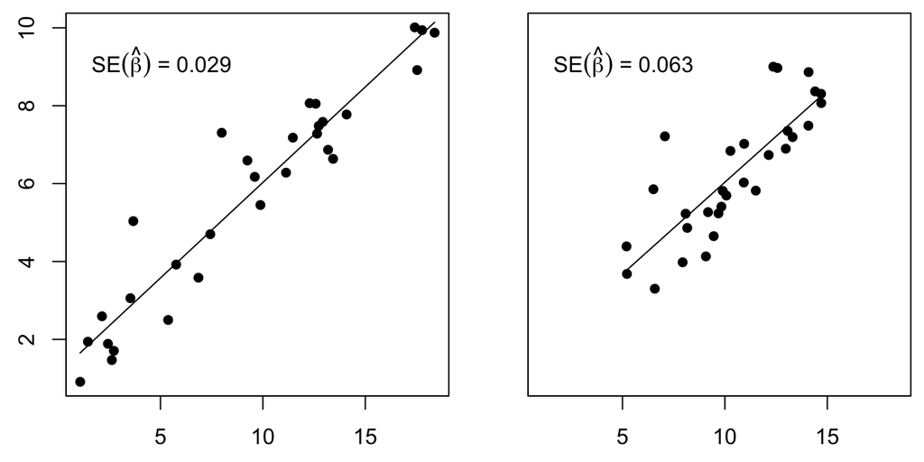